# Setup training data base

## Setup training data base

In case you have not already setup a training database please run

```r
NNtraining::createTrainingDB()
```

```
#> [1] TRUE TRUE TRUE
```

Assuming that you work on the R-server, this will copy the training data sets from the NNtraining package into your home directory in a sub folder called “training”. If the files already exists, nothing will happen. The training folder can then be used to read/write from, as if it was a real trial folder on the p-drive.

## Introduction

The NNcompare package can support the parallel review process when the parallel program is written in R. The `comparedf()` function from the arsenal package can be used to compare two data frames, and the `export()` function in the NNcompare package can be used to export a summary report of the comparison in various formats (HTML, Word, PDF, and github).

This vignette gives examples of how to use the NNcompare package in a parallel review process.

## Example 1: Adverse events by SOC/PT

A snippet of the table that should be parallel reviewed is shown here - it is a more or less standard adverse events table showing AEs by treatment, system organ class and preferred term:

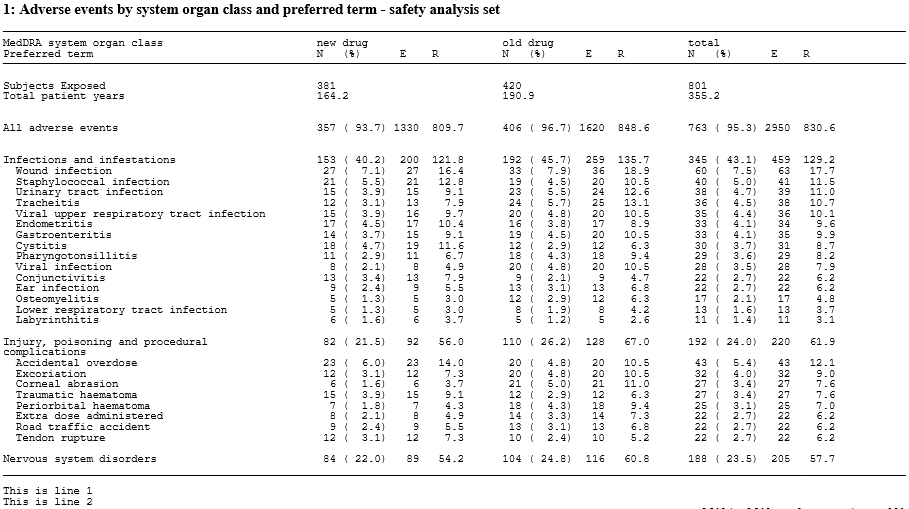

The following code shows how to access data on data, and how a parallel program for the Adverse events by SOC/PT could look like. The program is structured in the following way: 1. Access training data 2. Create the parallel programmed data set to compare to the output data set 3. Use the `comparedf()` function to compare the two data sets 4. Use the `export()` function to export the results of the comparison to a validation report

```r
library(NNBiostat)
library(NNcompare)
#library(arsenal)

# access to adam data and output datasets
# normally it is not necessary to specify the root argument
db <- nnaccess("4321", root = "~/training")

# NOTE that the argument root should not be used when using projstat
# e.g. db <- nnaccess(trial = "nn8640-exploratory", instance = "otgoa001",
#                     project = "nn8640")


# read adsl and adae data sets
adsl <- db$adam("adsl")
adae <- db$adam("adae")


# subset adsl - trial nn4654-4321, safety analysis set
# calculate treatment duration
adsl_f <-  adsl %>%
  filter(saffl == "Y" & studyid == "nn4654-4321" ) %>%
  mutate(trtdury = as.numeric(eotdt - randdt)/365.25)


# subset adae - trial nn4654-4321, safety analysis set, treatment emergent AEs
# join with adsl to add by subject treatment duration
adae_f <- adae %>%
  filter(saffl == "Y" & trtemfl == "Y" & studyid == "nn4654-4321") %>%
  left_join(select(adsl_f, c("trtdury", "usubjid")), by = "usubjid")

# duplicate rows to create "total" rows
adae_dup <- adae_f %>%
  mutate(trta = "total", trtan = 9999)
adsl_dup <- adsl_f %>%
  mutate(trta = "total", trtan = 9999)

adae_tot <- rbind(adae_f, adae_dup)
adsl_tot <- rbind(adsl_f, adsl_dup)

# calculate E, N by treatment, PT and SOC (aebodsys, aedecod)
adae_aedecod <- adae_tot %>%
  group_by(aebodsys, aedecod, trta) %>%
  summarise(E = n(),
            N = n_distinct(subjid),
            dur = sum(trtdury))
# calculate E, N by treatment, and PT (aebodsys)
adae_aebodsys <- adae_tot %>%
  group_by(aebodsys, trta) %>%
  summarise(E = n(),
            N = n_distinct(subjid),
            dur = sum(trtdury)) %>%
  mutate(aedecod = "")
# append adae tables
adae_sum <- rbind(adae_aedecod, adae_aebodsys) %>%
  mutate(aebodsys = ifelse(is.na(aebodsys), "", aebodsys))

# calculate E, N, and treatment duration by treatment
adsl_trt <- adsl_tot %>%
  group_by(trta) %>%
  summarise(E = n(),
            totN = n_distinct(subjid),
            totdur = sum(trtdury))
# join by treatment N and duration on adae and calculate P and R
taesocpt_parp <- left_join(adae_sum, select(adsl_trt, c("trta", "totdur", "totN")),
                              by = "trta") %>%
  mutate(P = 100 * N / totN, R = 100 * E / totdur)

# Read SAS dataset to compare
taesocpt <- db$output_datasets("taesocpt")

# run the export compare function - save in expected
sumCompare <- summary(comparedf(taesocpt,taesocpt_parp,
       by = c("trta", "aebodsys", "aedecod"), int.as.num = TRUE,
       factor.as.char = TRUE))

# run the export compare function
export(x = sumCompare, type = "html", db = db, subfolder = "validation_reports",
       filename = "taesocptal_parp", deleteRmd = TRUE)
```

```
#> processing file: taesocptal_parp.Rmd
#> output file: taesocptal_parp.knit.md
#> /bin/pandoc +RTS -K512m -RTS taesocptal_parp.utf8.md --to html4 --from markdown+autolink_bare_uris+tex_math_single_backslash --output taesocptal_parp.html --email-obfuscation none --self-contained --standalone --section-divs --table-of-contents --toc-depth 3 --template /opt/R/4.0.1/lib/R/site-lib…
#>
#> Output created: taesocptal_parp.html
#> saved to: ~/training/nn1234/nn1234-4321/current/stats/program/parprog/validation_reports
```

The report from the parallel program is by default placed in the “parprog” folder (this can be changed by using the folder argument) and in this case in a sub folder called “validation_reports”.

## Example 2: Most frequent (>=5%) adverse events by PT/SOC

A snippet of the table that should be parallel reviewed is shown here - it is an adverse events table showing 5% most frequent AEs by treatment, system organ class and preferred term:

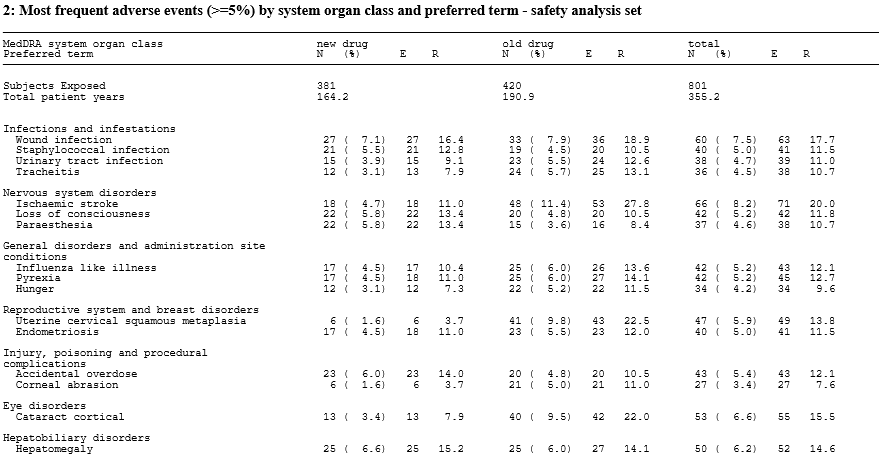

The parallel program is a continuation of the program from example 1 and based on the data set taesocpt_parp from that example. To adhere to the thoughts behind trace each parallel program should correspond 1:1 to the output program in the sense that there should be only one parallel program for each output program. This means that the ´comparedf()´ function could be called several times in one parallel program generating several reports for each parallel program. We recommend that the reports are named according to the output names with and “_parp” at the end and placed in a separate folder under the parprog folder - e.g. “validation_reports”.

```r
# filter taesocpt_parp to find SOCs where P>=5% for either of the treatments
aedecod_5mostfreq <- taesocpt_parp %>%
  ungroup() %>%
  filter(P>=5 & trta %in%  c("old drug", "new drug") & aedecod != "") %>%
  distinct(aedecod)

# restrict to SOCs where P>=5% for either of the treatments
taesocpt5_parp <- inner_join(taesocpt_parp, aedecod_5mostfreq,
                                     by = "aedecod") %>%
  select(c("aebodsys", "aedecod", "trta", "E", "N", "P", "R"))


# Read SAS dataset to compare
taesocpt5 <- db$output_datasets("taesocpt5") %>%
  filter(aedecod != "") %>%
  select(c("aebodsys", "aedecod", "trta", "E", "N", "P", "R"))

# run the export compare function - save in expected
sumCompare <- summary(comparedf(taesocpt5,taesocpt5_parp,
                                by = c("trta", "aebodsys", "aedecod"),
                                int.as.num = TRUE, factor.as.char = TRUE))
# run the export compare function
export(x = sumCompare, type = "html", db = db, subfolder = "validation_reports",
       filename = "taesocpt5_parp", deleteRmd = TRUE)
```

```
#> processing file: taesocpt5_parp.Rmd
#> output file: taesocpt5_parp.knit.md
#> /bin/pandoc +RTS -K512m -RTS taesocpt5_parp.utf8.md --to html4 --from markdown+autolink_bare_uris+tex_math_single_backslash --output taesocpt5_parp.html --email-obfuscation none --self-contained --standalone --section-divs --table-of-contents --toc-depth 3 --template /opt/R/4.0.1/lib/R/site-libra…
#>
#> Output created: taesocpt5_parp.html
#> saved to: ~/training/nn1234/nn1234-4321/current/stats/program/parprog/validation_reports
```

## Summary of comparisons

For each comparison of data sets the `export()` function exports both a summary report as described in the two examples above, and also a short summary file which is placed together with the summary report. The short summary report contains a summary of the differences found: “false” indicates that no differences were found, and “true” that differences exist in “Number of columns”, “Number of rows”, and / or “Compared values”. To provide overview of all comparisons done in a given instance these short summary files can be combined by using the `combineDFcomp()` function, which concatenates the short summary files into one HTML overview file.

```r
path <- "~/training/nn1234/nn1234-4321/current/stats/program/parprog/validation_reports"

# prepare overall summary report of short summary files
combined_summary <- combineDFComp(path = path, filename = "combined_summary")
```

The last column in the HTML overview file contains a link to the detailed summary report for the parallel program in scope.